# Rupesh_Project_CNN

**Data Description:**

You are provided with a dataset of images of plant seedlings at various stages of grown. Each image has a filename that is its unique id. The dataset comprises 12 plant species. The goal of the project is to create a classifier capable of determining a plant's species from a photo.

**Context:**  
Can you differentiate a weed from a crop seedling?  
The ability to do so effectively can mean better crop yields and better stewardship of the environment.  
The Aarhus University Signal Processing group, in collaboration with University of Southern Denmark, has recently released a dataset containing images of unique plants belonging to 12 species at several growth stages

**Objective:**  
To implement the techniques learnt as a part of the course.  
**Learning Outcomes:**

- Pre-processing of image data.
- Visualization of images.
- Building CNN.
- Evaluate the Model.
- The motive of the project is to make the learners capable to handle images/image classification problems, during this process you should also be capable to handle real image files, not just limited to a numpy array of image pixels.

```python
!pip install opencv-python
```

#### Import the libraries, load dataset, print shape of data, visualize the images in dataset. (5 Marks)

```python
# Importing the important libraries

import cv2
import numpy as np
import pandas as pd

# For plotting
import seaborn as sns
import matplotlib.pyplot as plt
%matplotlib inline

from sklearn import svm
from sklearn.model_selection import train_test_split

# For creating cnn model
from tensorflow.keras.models import Sequential
from tensorflow.keras.layers import Conv2D,Flatten,Dense

# Loading the image file of dataset
images = np.load('images.npy')

# Loading the labels file of dataset
labels = pd.read_csv('Labels.csv')
```

```python
# Checking the shape of Images and labels

print(images.shape)
print(labels.shape)
```

```
(4750, 128, 128, 3)
(4750, 1)
```

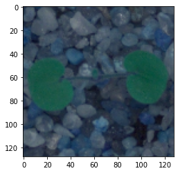

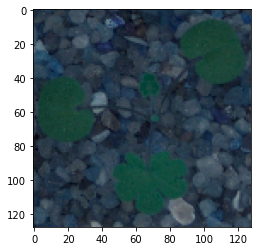

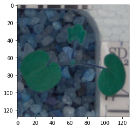

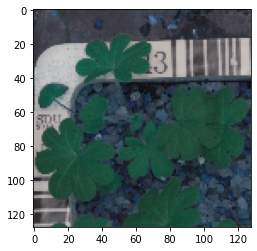

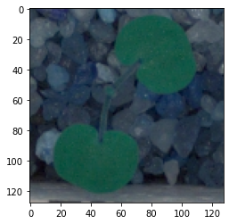

```python
# Checking the images in dataset

for i in range(0,5):
    plt.imshow(images[i])
    plt.show()
```

```python
labels.head()
```

|  | Label |
| --- | --- |
| 0 | Small-flowered Cranesbill |
| 1 | Small-flowered Cranesbill |
| 2 | Small-flowered Cranesbill |
| 3 | Small-flowered Cranesbill |
| 4 | Small-flowered Cranesbill |

#### Data Pre-processing: (15 Marks)

a. Normalization.  
b. Gaussian Blurring.  
c. Visualize data after pre-processing.

```python
# Normalizing the data

images = images.astype('float32') / 255.0
```

```python
# Gaussian Blurring.
# we will try kernel sizes of 7x7 and 5x5
# Applying the gaussian blur kernel (7X7) to each 128x128 pixels array (image) to reduce the noise in the image

for idx, img in enumerate(images):
  images[idx] = cv2.GaussianBlur(img, (7, 7), cv2.BORDER_DEFAULT)
```

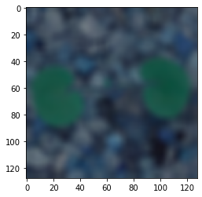

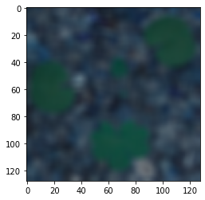

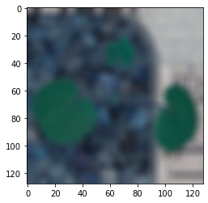

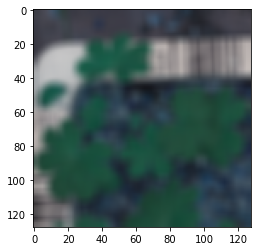

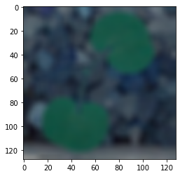

```python
# Plotting the de-noised image generated in the previous step from the Gaussian blur.

for i in range(0,5):
    plt.imshow(images[i], cmap='gray')
    plt.show()
```

```python
# Gaussian Blurring.
# Applying the gaussian blur kernel (5X5) to each 128x128 pixels array (image) to reduce the noise in the image

for idx, img in enumerate(images):
  images[idx] = cv2.GaussianBlur(img, (5, 5), 0)
```

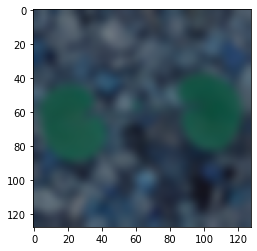

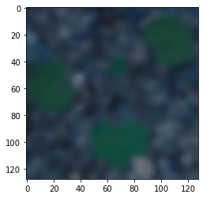

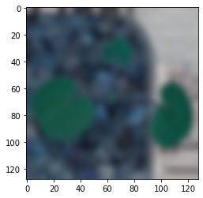

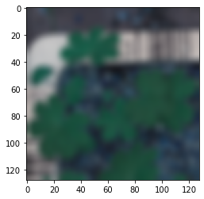

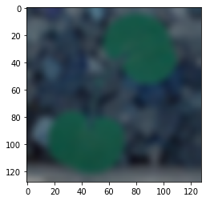

```python
# Plotting the de-noised image generated by applying Gaussian blur.

for i in range(0,5):
    plt.imshow(images[i], cmap='gray')
    plt.show()
```

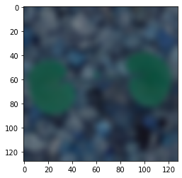

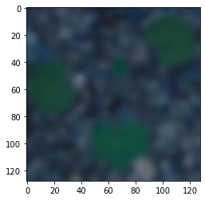

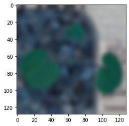

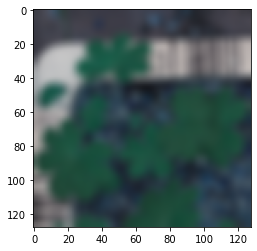

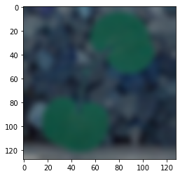

```python
# C. Visualize data after pre-processing.

for i in range(0,5):
    plt.imshow(images[i])
    plt.show()
```